# Using Ensembles to predict Gamma Particles

Insofe Lab Assignment for Ensemble Learning

30 July 2017

## Agenda

- Read in the data
- Data Pre-processing
- Build Multiple Models
- Stack those models
- Report Metrics of Models on Test Data

# Reading & Understanding the Data

- Read in the .csv file

```r
# change your working directory using the "setwd()" function, if your dataset is located elsewhere

gamma_data <- read.csv("gamma_data.csv")
```

- Get a feel for the data using the str() function

```r
str(gamma_data)
```

```
## 'data.frame':    3804 obs. of  11 variables:
##  $ fLength : num  48.2 18.9 60.5 29.5 20.4 ...
##  $ fWidth  : num  17.36 16.46 33.11 22.46 9.05 ...
##  $ fSize   : num  3.03 2.44 3.19 2.63 2.34 ...
##  $ fConc   : num  0.253 0.528 0.468 0.308 0.636 ...
##  $ fConc1  : num  0.151 0.293 0.246 0.174 0.389 ...
##  $ fAsym   : num  8.57 25.13 14.3 18.12 22.27 ...
##  $ fM3Long : num  38.1 -6.54 -33.88 22.7 12.95 ...
##  $ fM3Trans: num  10.59 -16.93 28.83 13.17 -2.04 ...
##  $ fAlpha  : num  4.79 11.46 8.29 48.04 43 ...
##  $ fDist   : num  219.1 162.8 372.6 214.1 66.2 ...
##  $ class   : int  1 1 1 1 1 1 1 1 1 1 ...
```

The dataset has 3804 observations with 11 variables, the descriptions of the variables are given below :

1. **fLength** : continuous # major axis of ellipse [mm]
2. **fWidth** : continuous # minor axis of ellipse [mm]
3. **fSize** : continuous # 10-log of sum of content of all pixels [in #phot]
4. **fConc** : continuous # ratio of sum of two highest pixels over fSize [ratio]
5. **fConc1** : continuous # ratio of highest pixel over fSize [ratio]
6. **fAsym** : continuous # distance from highest pixel to center, projected onto major axis [mm]
7. **fM3Long** : continuous # 3rd root of third moment along major axis [mm]
8. **fM3Trans**: continuous # 3rd root of third moment along minor axis [mm]
9. **fAlpha** : continuous # angle of major axis with vector to origin [deg]
10. **fDist** : continuous # distance from origin to center of ellipse [mm]
11. **class** : 1, 0 # 1 - gamma (signal), 0 - hadron (background)
- Let’s look at the head and tail of the dataset

```r
head(gamma_data)
```

```
##   fLength  fWidth  fSize  fConc fConc1   fAsym  fM3Long fM3Trans  fAlpha
## 1 48.2468 17.3565 3.0332 0.2529 0.1515  8.5730  38.0957  10.5868  4.7920
## 2 18.8562 16.4600 2.4385 0.5282 0.2933 25.1269  -6.5401 -16.9327 11.4610
## 3 60.4580 33.1061 3.1944 0.4679 0.2464 14.3000 -33.8765  28.8315  8.2920
## 4 29.4741 22.4581 2.6258 0.3077 0.1740 18.1242  22.7035  13.1673 48.0364
## 5 20.3836  9.0462 2.3365 0.6359 0.3894 22.2700  12.9487  -2.0403 43.0032
## 6 23.5647  9.9926 2.2095 0.5679 0.3364 30.0056 -13.8665  -8.2600 26.5328
##      fDist class
## 1 219.0870     1
## 2 162.8480     1
## 3 372.5680     1
## 4 214.1260     1
## 5  66.1667     1
## 6 185.1890     1
```

```r
tail(gamma_data)
```

```
##       fLength  fWidth  fSize  fConc fConc1     fAsym   fM3Long fM3Trans
## 3799  29.8353 11.3519 2.4449 0.4890 0.2948    9.9236   -9.0429  16.2790
## 3800 207.2530 75.8327 4.1476 0.0739 0.0371 -242.4960 -180.0290 -57.8600
## 3801 172.2442 20.1926 2.9009 0.2887 0.1940  124.5990  112.9452 -21.4436
## 3802  32.4902 10.6723 2.4742 0.4664 0.2735  -27.0097  -21.1687   8.4813
## 3803  43.2980 17.3545 2.8307 0.2877 0.1646  -60.1842  -33.8513  -3.6545
## 3804  21.3846 10.9170 2.6161 0.5857 0.3934   15.2618   11.5245   2.8766
##       fAlpha    fDist class
## 3799 17.1944 230.5486     0
## 3800 74.5740 259.3160     0
## 3801 28.9553 210.8496     0
## 3802 69.1730 120.6680     0
## 3803 78.4099 224.8299     0
## 3804  2.4229 106.8258     0
```

# Data Pre-processing

- Convert the class column into a factor

```r
gamma_data$class <- as.factor(gamma_data$class)
```

- Split the dataset into train and test using using stratified sampling

```r
library(caret)
set.seed(1234)

index_train <- createDataPartition(gamma_data$class, p = 0.7, list = F)

pre_train <- gamma_data[index_train, ]

pre_test <- gamma_data[-index_train, ]
```

- Split the train data further into train and validation datasets

```r
index_val <- createDataPartition(pre_train$class, p = 0.7, list = F)

pre_train_2 <- pre_train[index_val, ]

pre_val <- pre_train[-index_val, ]
```

- Standardize all the real valued variables in the dataset using only the train data

```r
std_method <- preProcess(pre_train_2, method = c("center", "scale"))

train_data <- predict(std_method, pre_train_2)

test_data <- predict(std_method, pre_test)

val_data <- predict(std_method, pre_val)
```

# Building Multiple Models

- Build multiple types of models

## Linear SVM

- Build a linear SVM Classifier

```r
library(e1071)

model_svm <- svm(class ~ . , train_data, kernel = "linear")

summary(model_svm)
```

```
##
## Call:
## svm(formula = class ~ ., data = train_data, kernel = "linear")
##
##
## Parameters:
##    SVM-Type:  C-classification
##  SVM-Kernel:  linear
##        cost:  1
##       gamma:  0.1
##
## Number of Support Vectors:  903
##
##  ( 452 451 )
##
##
## Number of Classes:  2
##
## Levels:
##  0 1
```

```r
preds_svm <- predict(model_svm, val_data)

confusionMatrix(preds_svm, val_data$class)
```

```
## Confusion Matrix and Statistics
##
##           Reference
## Prediction   0   1
##          0 171  56
##          1 104 467
##
##                Accuracy : 0.7995
##                  95% CI : (0.77, 0.8268)
##     No Information Rate : 0.6554
##     P-Value [Acc > NIR] : < 2.2e-16
##
##                   Kappa : 0.537
##  Mcnemar's Test P-Value : 0.0002027
##
##             Sensitivity : 0.6218
##             Specificity : 0.8929
##          Pos Pred Value : 0.7533
##          Neg Pred Value : 0.8179
##              Prevalence : 0.3446
##          Detection Rate : 0.2143
##    Detection Prevalence : 0.2845
##       Balanced Accuracy : 0.7574
##
##        'Positive' Class : 0
##
```

```r
preds_train_svm <- predict(model_svm)
```

## Tanhdot kernel SVM

- Build a Tanhdot kernel SVM Classifier

```r
library(kernlab)
model_svm_th <- ksvm(class ~ . , train_data, kernel = "tanhdot")
preds_svm_th <- predict(model_svm_th, val_data)

confusionMatrix(preds_svm_th, val_data$class)
```

```
## Confusion Matrix and Statistics
##
##           Reference
## Prediction   0   1
##          0  92 171
##          1 183 352
##
##                Accuracy : 0.5564
##                  95% CI : (0.5211, 0.5912)
##     No Information Rate : 0.6554
##     P-Value [Acc > NIR] : 1.0000
##
##                   Kappa : 0.0077
##  Mcnemar's Test P-Value : 0.5588
##
##             Sensitivity : 0.3345
##             Specificity : 0.6730
##          Pos Pred Value : 0.3498
##          Neg Pred Value : 0.6579
##              Prevalence : 0.3446
##          Detection Rate : 0.1153
##    Detection Prevalence : 0.3296
##       Balanced Accuracy : 0.5038
##
##        'Positive' Class : 0
##
```

```r
preds_train_svm_th <- predict(model_svm_th)
```

## Anovadot kernel SVM

- Build a Anovadot kernel SVM Classifier

```r
model_svm_an <- ksvm(class ~ . , train_data, kernel = "anovadot")
preds_svm_an <- predict(model_svm_an, val_data)

confusionMatrix(preds_svm_an, val_data$class)
```

```
## Confusion Matrix and Statistics
##
##           Reference
## Prediction   0   1
##          0 197  46
##          1  78 477
##
##                Accuracy : 0.8446
##                  95% CI : (0.8176, 0.8691)
##     No Information Rate : 0.6554
##     P-Value [Acc > NIR] : < 2.2e-16
##
##                   Kappa : 0.6462
##  Mcnemar's Test P-Value : 0.005371
##
##             Sensitivity : 0.7164
##             Specificity : 0.9120
##          Pos Pred Value : 0.8107
##          Neg Pred Value : 0.8595
##              Prevalence : 0.3446
##          Detection Rate : 0.2469
##    Detection Prevalence : 0.3045
##       Balanced Accuracy : 0.8142
##
##        'Positive' Class : 0
##
```

```r
preds_train_svm_an <- predict(model_svm_th)
```

## Radial Basis Kernel SVM

- Build a Radial Basis Kernel SVM Classifier

```r
model_svm_rb <- ksvm(class ~ . , train_data, kernel = "rbfdot")

preds_svm_rb <- predict(model_svm_rb, val_data)

confusionMatrix(preds_svm_rb, val_data$class)
```

```
## Confusion Matrix and Statistics
##
##           Reference
## Prediction   0   1
##          0 193  30
##          1  82 493
##
##                Accuracy : 0.8596
##                  95% CI : (0.8336, 0.883)
##     No Information Rate : 0.6554
##     P-Value [Acc > NIR] : < 2.2e-16
##
##                   Kappa : 0.6747
##  Mcnemar's Test P-Value : 1.442e-06
##
##             Sensitivity : 0.7018
##             Specificity : 0.9426
##          Pos Pred Value : 0.8655
##          Neg Pred Value : 0.8574
##              Prevalence : 0.3446
##          Detection Rate : 0.2419
##    Detection Prevalence : 0.2794
##       Balanced Accuracy : 0.8222
##
##        'Positive' Class : 0
##
```

```r
preds_train_svm_rb <- predict(model_svm_th)
```

## Random Forest

- Build a Random Forest Model

```r
library(randomForest)
model_rf <- randomForest(class ~ . , train_data)

importance(model_rf)
```

```
##          MeanDecreaseGini
## fLength         113.11533
## fWidth           90.57565
## fSize           107.15337
## fConc            52.26969
## fConc1           48.26665
## fAsym            48.55168
## fM3Long          76.95770
## fM3Trans         46.89091
## fAlpha          205.84051
## fDist            53.07565
```

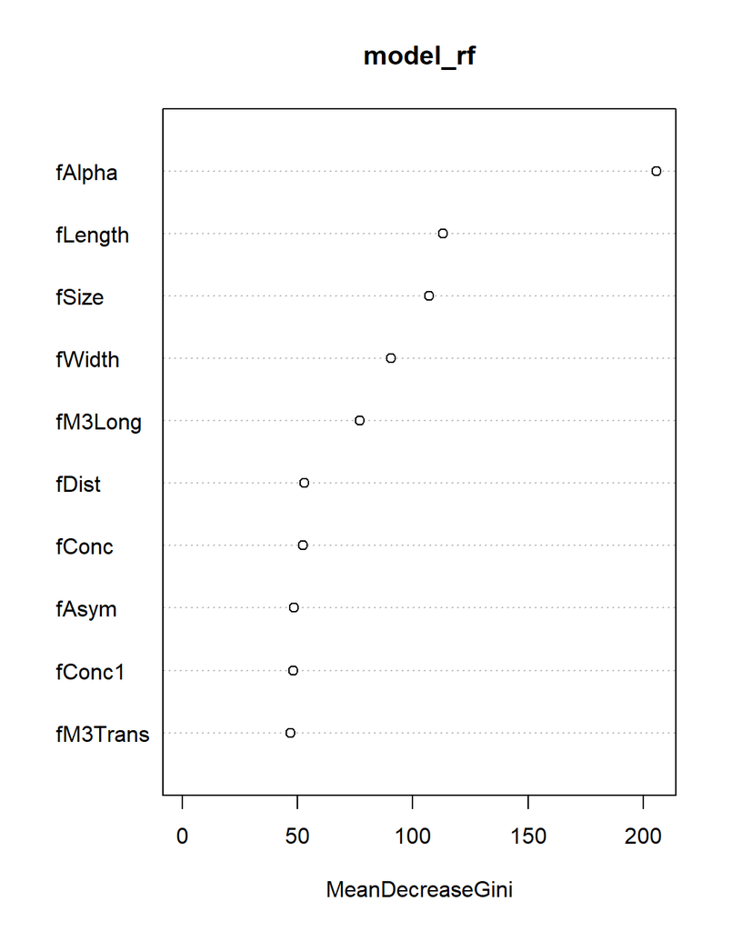

```r
varImpPlot(model_rf)
```

```r
preds_rf <- predict(model_rf, val_data)

confusionMatrix(preds_rf, val_data$class)
```

```
## Confusion Matrix and Statistics
##
##           Reference
## Prediction   0   1
##          0 202  33
##          1  73 490
##
##                Accuracy : 0.8672
##                  95% CI : (0.8416, 0.89)
##     No Information Rate : 0.6554
##     P-Value [Acc > NIR] : < 2.2e-16
##
##                   Kappa : 0.6954
##  Mcnemar's Test P-Value : 0.0001519
##
##             Sensitivity : 0.7345
##             Specificity : 0.9369
##          Pos Pred Value : 0.8596
##          Neg Pred Value : 0.8703
##              Prevalence : 0.3446
##          Detection Rate : 0.2531
##    Detection Prevalence : 0.2945
##       Balanced Accuracy : 0.8357
##
##        'Positive' Class : 0
##
```

```r
preds_train_rf <- predict(model_rf)
```

## KNN

- Initialize a KNN classifier

```r
model_knn <- knn3(class ~ . , train_data, k = 5)

preds_k <- predict(model_knn, val_data)

preds_knn <- ifelse(preds_k[, 1] > preds_k[, 2], 0, 1)

confusionMatrix(preds_knn, val_data$class)
```

```
## Confusion Matrix and Statistics
##
##           Reference
## Prediction   0   1
##          0 170  41
##          1 105 482
##
##                Accuracy : 0.817
##                  95% CI : (0.7884, 0.8433)
##     No Information Rate : 0.6554
##     P-Value [Acc > NIR] : < 2.2e-16
##
##                   Kappa : 0.5713
##  Mcnemar's Test P-Value : 1.849e-07
##
##             Sensitivity : 0.6182
##             Specificity : 0.9216
##          Pos Pred Value : 0.8057
##          Neg Pred Value : 0.8211
##              Prevalence : 0.3446
##          Detection Rate : 0.2130
##    Detection Prevalence : 0.2644
##       Balanced Accuracy : 0.7699
##
##        'Positive' Class : 0
##
```

```r
preds_train_k <- predict(model_knn, train_data)

preds_train_knn <- ifelse(preds_train_k[, 1] > preds_train_k[, 2], 0, 1)
```

## Decision Trees

- Build a CART Tree

```r
library(rpart)

model_dt <- rpart(class ~ . , train_data, control = rpart.control(cp = 0.01, xval = 10))

preds_dt <- predict(model_dt, val_data)

preds_tree <- ifelse(preds_dt[, 1] > preds_dt[, 2], 0, 1)

confusionMatrix(preds_tree, val_data$class)
```

```
## Confusion Matrix and Statistics
##
##           Reference
## Prediction   0   1
##          0 188  48
##          1  87 475
##
##                Accuracy : 0.8308
##                  95% CI : (0.803, 0.8562)
##     No Information Rate : 0.6554
##     P-Value [Acc > NIR] : < 2.2e-16
##
##                   Kappa : 0.6125
##  Mcnemar's Test P-Value : 0.001074
##
##             Sensitivity : 0.6836
##             Specificity : 0.9082
##          Pos Pred Value : 0.7966
##          Neg Pred Value : 0.8452
##              Prevalence : 0.3446
##          Detection Rate : 0.2356
##    Detection Prevalence : 0.2957
##       Balanced Accuracy : 0.7959
##
##        'Positive' Class : 0
##
```

```r
preds_train_dt <- predict(model_dt)

preds_train_tree <- ifelse(preds_train_dt[, 1] > preds_train_dt[, 2], 0, 1)
```

## Bagged Decision Trees

- Build CART Trees using bagging

```r
library(ipred)
set.seed(1234)

model_tree_bag <- bagging(class ~ . , data=train_data, control = rpart.control(cp = 0.01, xval = 10))

preds_tree_bag <- predict(model_tree_bag, val_data)

confusionMatrix(preds_tree_bag, val_data$class)
```

```
## Confusion Matrix and Statistics
##
##           Reference
## Prediction   0   1
##          0 189  41
##          1  86 482
##
##                Accuracy : 0.8409
##                  95% CI : (0.8136, 0.8656)
##     No Information Rate : 0.6554
##     P-Value [Acc > NIR] : < 2.2e-16
##
##                   Kappa : 0.6335
##  Mcnemar's Test P-Value : 9.447e-05
##
##             Sensitivity : 0.6873
##             Specificity : 0.9216
##          Pos Pred Value : 0.8217
##          Neg Pred Value : 0.8486
##              Prevalence : 0.3446
##          Detection Rate : 0.2368
##    Detection Prevalence : 0.2882
##       Balanced Accuracy : 0.8044
##
##        'Positive' Class : 0
##
```

```r
preds_train_tree_bag <- predict(model_tree_bag)
```

## GBM Model

- Build a GBM Model

```r
library(gbm)
library(pROC)
train_data$class <- as.numeric(as.character(train_data$class))

val_data$class <- as.numeric(as.character(val_data$class))

model_gbm <- gbm(class ~ . , cv.folds = 8, interaction.depth = 3,
                 shrinkage = 0.02, distribution= 'bernoulli',
                 data = train_data, n.trees = 2500)

gbm.perf(model_gbm)
```

```
## Using cv method...
```

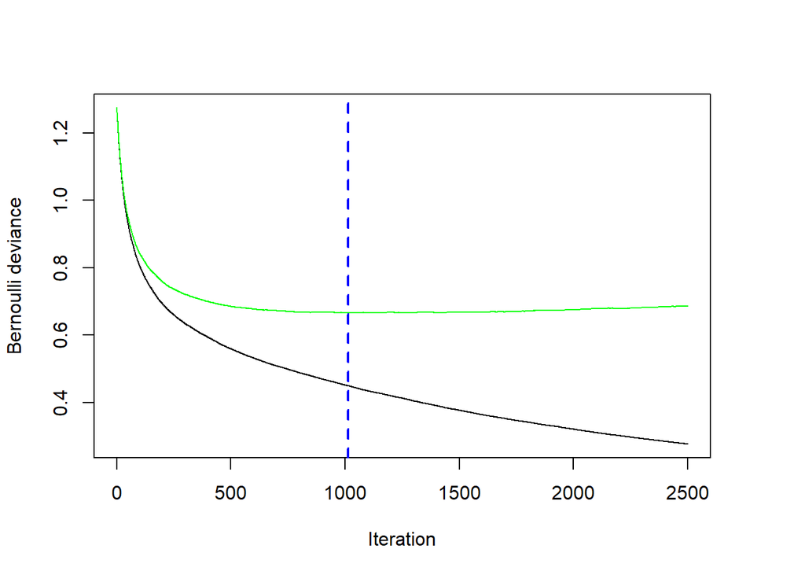

```
## [1] 1013
```

```r
preds_g <- predict(model_gbm, type = 'response')
```

```
## Using 1013 trees...
```

```r
gbm_roc <- roc(train_data$class, preds_g)

cutoff_gbm <- coords(gbm_roc, "best", ret = "threshold")

preds_train_gbm <- ifelse(preds_g >= cutoff_gbm, 1, 0)

preds_val_g <- predict(model_gbm, val_data, type = 'response')
```

```
## Using 1013 trees...
```

```r
preds_gbm <- ifelse(preds_val_g >= cutoff_gbm, 1, 0)

confusionMatrix(preds_gbm, val_data$class)
```

```
## Confusion Matrix and Statistics
##
##           Reference
## Prediction   0   1
##          0 218  66
##          1  57 457
##
##                Accuracy : 0.8459
##                  95% CI : (0.8189, 0.8702)
##     No Information Rate : 0.6554
##     P-Value [Acc > NIR] : <2e-16
##
##                   Kappa : 0.6614
##  Mcnemar's Test P-Value : 0.4707
##
##             Sensitivity : 0.7927
##             Specificity : 0.8738
##          Pos Pred Value : 0.7676
##          Neg Pred Value : 0.8891
##              Prevalence : 0.3446
##          Detection Rate : 0.2732
##    Detection Prevalence : 0.3559
##       Balanced Accuracy : 0.8333
##
##        'Positive' Class : 0
##
```

# Building a Stacked Ensemble

- Build a stacked ensemble model using all the models from above, by integrating the predictions on the training and validation datasets

```r
train_preds_df <- data.frame(svm = preds_train_svm, svm_th = preds_train_svm_th,
                       svm_an = preds_train_svm_an, svm_rb = preds_train_svm_rb,
                       rf = preds_train_rf, knn = preds_train_knn,
                       tree = preds_train_tree, tree_bag = preds_train_tree_bag,
                       gbm = preds_train_gbm, class = train_data$class)

val_preds_df <- data.frame(svm = preds_svm, svm_th = preds_svm_th,
                       svm_an = preds_svm_an, svm_rb = preds_svm_rb,
                       rf = preds_rf, knn = preds_knn, tree = preds_tree,
                       tree_bag = preds_tree_bag, gbm = preds_gbm,
                       class = val_data$class)

stack_df <- rbind(train_preds_df, val_preds_df)

stack_df$class <- as.factor(stack_df$class)
```

```r
numeric_st_df <- sapply(stack_df[, !(names(stack_df) %in% "class")],
                        function(x) as.numeric(as.character(x)))

pca_stack <- prcomp(numeric_st_df, scale = F)

predicted_stack <- as.data.frame(predict(pca_stack, numeric_st_df))[1:4]

stacked_df <- data.frame(predicted_stack, class = stack_df[, (names(stack_df) %in% "class")])

stacked_model <- svm(class ~ . , stacked_df, kernel = "linear")
```

# Reporting Metrics for the Models on Test Data

- Report evaluation metrics for the above models on the test data

```r
svm_test <- predict(model_svm, test_data)

svm_test_th <- predict(model_svm_th, test_data)

svm_an_test <- predict(model_svm_an, test_data)

svm_rb_test <- predict(model_svm_rb, test_data)

rf_test <- predict(model_rf, test_data)

knn_test <- ifelse(predict(model_knn, test_data)[, 1] >  predict(model_knn, test_data)[, 2], 0, 1)

dt_test <- ifelse(predict(model_dt, test_data)[, 1] >  predict(model_dt, test_data)[, 2], 0, 1)

bag_tree_test <- predict(model_tree_bag, test_data)

test_data$class <- as.numeric(as.character(test_data$class))

gbm_test <- ifelse(predict(model_gbm, test_data, type = 'response') >= cutoff_gbm, 1, 0)
```

```
## Using 1013 trees...
```

```r
stack_df_test <- data.frame(svm = svm_test, svm_th = svm_test_th,
                            svm_an = svm_an_test, svm_rb = svm_rb_test,
                            rf = rf_test, knn = knn_test, tree = dt_test,
                            tree_bag = bag_tree_test, gbm = gbm_test,
                            class = test_data$class)

stack_df_test$class <- as.factor(stack_df_test$class)
```

```r
numeric_st_df_test <- sapply(stack_df_test[, !(names(stack_df_test) %in% "class")],
                        function(x) as.numeric(as.character(x)))

predicted_stack_test <- as.data.frame(predict(pca_stack, numeric_st_df_test))[1:4]

stacked_df_test <- data.frame(predicted_stack_test, class = stack_df_test[, (names(stack_df_test) %in% "class")])

preds_st_test <-  predict(stacked_model, stacked_df_test)
```

```r
confusionMatrix(svm_test, test_data$class)
```

```
## Confusion Matrix and Statistics
##
##           Reference
## Prediction   0   1
##          0 224  72
##          1 169 675
##
##                Accuracy : 0.7886
##                  95% CI : (0.7637, 0.812)
##     No Information Rate : 0.6553
##     P-Value [Acc > NIR] : < 2.2e-16
##
##                   Kappa : 0.503
##  Mcnemar's Test P-Value : 6.254e-10
##
##             Sensitivity : 0.5700
##             Specificity : 0.9036
##          Pos Pred Value : 0.7568
##          Neg Pred Value : 0.7998
##              Prevalence : 0.3447
##          Detection Rate : 0.1965
##    Detection Prevalence : 0.2596
##       Balanced Accuracy : 0.7368
##
##        'Positive' Class : 0
##
```

```r
confusionMatrix(svm_test_th, test_data$class)
```

```
## Confusion Matrix and Statistics
##
##           Reference
## Prediction   0   1
##          0 132 236
##          1 261 511
##
##                Accuracy : 0.564
##                  95% CI : (0.5347, 0.5931)
##     No Information Rate : 0.6553
##     P-Value [Acc > NIR] : 1.0000
##
##                   Kappa : 0.0203
##  Mcnemar's Test P-Value : 0.2817
##
##             Sensitivity : 0.3359
##             Specificity : 0.6841
##          Pos Pred Value : 0.3587
##          Neg Pred Value : 0.6619
##              Prevalence : 0.3447
##          Detection Rate : 0.1158
##    Detection Prevalence : 0.3228
##       Balanced Accuracy : 0.5100
##
##        'Positive' Class : 0
##
```

```r
confusionMatrix(svm_an_test, test_data$class)
```

```
## Confusion Matrix and Statistics
##
##           Reference
## Prediction   0   1
##          0 281  50
##          1 112 697
##
##                Accuracy : 0.8579
##                  95% CI : (0.8363, 0.8777)
##     No Information Rate : 0.6553
##     P-Value [Acc > NIR] : < 2.2e-16
##
##                   Kappa : 0.6732
##  Mcnemar's Test P-Value : 1.646e-06
##
##             Sensitivity : 0.7150
##             Specificity : 0.9331
##          Pos Pred Value : 0.8489
##          Neg Pred Value : 0.8616
##              Prevalence : 0.3447
##          Detection Rate : 0.2465
##    Detection Prevalence : 0.2904
##       Balanced Accuracy : 0.8240
##
##        'Positive' Class : 0
##
```

```r
confusionMatrix(svm_rb_test, test_data$class)
```

```
## Confusion Matrix and Statistics
##
##           Reference
## Prediction   0   1
##          0 283  42
##          1 110 705
##
##                Accuracy : 0.8667
##                  95% CI : (0.8455, 0.8859)
##     No Information Rate : 0.6553
##     P-Value [Acc > NIR] : < 2.2e-16
##
##                   Kappa : 0.6923
##  Mcnemar's Test P-Value : 5.498e-08
##
##             Sensitivity : 0.7201
##             Specificity : 0.9438
##          Pos Pred Value : 0.8708
##          Neg Pred Value : 0.8650
##              Prevalence : 0.3447
##          Detection Rate : 0.2482
##    Detection Prevalence : 0.2851
##       Balanced Accuracy : 0.8319
##
##        'Positive' Class : 0
##
```

```r
confusionMatrix(rf_test, test_data$class)
```

```
## Confusion Matrix and Statistics
##
##           Reference
## Prediction   0   1
##          0 287  46
##          1 106 701
##
##                Accuracy : 0.8667
##                  95% CI : (0.8455, 0.8859)
##     No Information Rate : 0.6553
##     P-Value [Acc > NIR] : < 2.2e-16
##
##                   Kappa : 0.6938
##  Mcnemar's Test P-Value : 1.705e-06
##
##             Sensitivity : 0.7303
##             Specificity : 0.9384
##          Pos Pred Value : 0.8619
##          Neg Pred Value : 0.8686
##              Prevalence : 0.3447
##          Detection Rate : 0.2518
##    Detection Prevalence : 0.2921
##       Balanced Accuracy : 0.8344
##
##        'Positive' Class : 0
##
```

```r
confusionMatrix(knn_test, test_data$class)
```

```
## Confusion Matrix and Statistics
##
##           Reference
## Prediction   0   1
##          0 241  43
##          1 152 704
##
##                Accuracy : 0.8289
##                  95% CI : (0.8058, 0.8504)
##     No Information Rate : 0.6553
##     P-Value [Acc > NIR] : < 2.2e-16
##
##                   Kappa : 0.5948
##  Mcnemar's Test P-Value : 1.042e-14
##
##             Sensitivity : 0.6132
##             Specificity : 0.9424
##          Pos Pred Value : 0.8486
##          Neg Pred Value : 0.8224
##              Prevalence : 0.3447
##          Detection Rate : 0.2114
##    Detection Prevalence : 0.2491
##       Balanced Accuracy : 0.7778
##
##        'Positive' Class : 0
##
```

```r
confusionMatrix(dt_test, test_data$class)
```

```
## Confusion Matrix and Statistics
##
##           Reference
## Prediction   0   1
##          0 265  63
##          1 128 684
##
##                Accuracy : 0.8325
##                  95% CI : (0.8095, 0.8537)
##     No Information Rate : 0.6553
##     P-Value [Acc > NIR] : < 2.2e-16
##
##                   Kappa : 0.614
##  Mcnemar's Test P-Value : 3.641e-06
##
##             Sensitivity : 0.6743
##             Specificity : 0.9157
##          Pos Pred Value : 0.8079
##          Neg Pred Value : 0.8424
##              Prevalence : 0.3447
##          Detection Rate : 0.2325
##    Detection Prevalence : 0.2877
##       Balanced Accuracy : 0.7950
##
##        'Positive' Class : 0
##
```

```r
confusionMatrix(bag_tree_test, test_data$class)
```

```
## Confusion Matrix and Statistics
##
##           Reference
## Prediction   0   1
##          0 261  47
##          1 132 700
##
##                Accuracy : 0.843
##                  95% CI : (0.8205, 0.8636)
##     No Information Rate : 0.6553
##     P-Value [Acc > NIR] : < 2.2e-16
##
##                   Kappa : 0.6337
##  Mcnemar's Test P-Value : 3.42e-10
##
##             Sensitivity : 0.6641
##             Specificity : 0.9371
##          Pos Pred Value : 0.8474
##          Neg Pred Value : 0.8413
##              Prevalence : 0.3447
##          Detection Rate : 0.2289
##    Detection Prevalence : 0.2702
##       Balanced Accuracy : 0.8006
##
##        'Positive' Class : 0
##
```

```r
confusionMatrix(gbm_test, test_data$class)
```

```
## Confusion Matrix and Statistics
##
##           Reference
## Prediction   0   1
##          0 322  81
##          1  71 666
##
##                Accuracy : 0.8667
##                  95% CI : (0.8455, 0.8859)
##     No Information Rate : 0.6553
##     P-Value [Acc > NIR] : <2e-16
##
##                   Kappa : 0.7066
##  Mcnemar's Test P-Value : 0.4654
##
##             Sensitivity : 0.8193
##             Specificity : 0.8916
##          Pos Pred Value : 0.7990
##          Neg Pred Value : 0.9037
##              Prevalence : 0.3447
##          Detection Rate : 0.2825
##    Detection Prevalence : 0.3535
##       Balanced Accuracy : 0.8555
##
##        'Positive' Class : 0
##
```

```r
confusionMatrix(preds_st_test, stacked_df_test$class)
```

```
## Confusion Matrix and Statistics
##
##           Reference
## Prediction   0   1
##          0 305  58
##          1  88 689
##
##                Accuracy : 0.8719
##                  95% CI : (0.8511, 0.8908)
##     No Information Rate : 0.6553
##     P-Value [Acc > NIR] : < 2e-16
##
##                   Kappa : 0.7113
##  Mcnemar's Test P-Value : 0.01639
##
##             Sensitivity : 0.7761
##             Specificity : 0.9224
##          Pos Pred Value : 0.8402
##          Neg Pred Value : 0.8867
##              Prevalence : 0.3447
##          Detection Rate : 0.2675
##    Detection Prevalence : 0.3184
##       Balanced Accuracy : 0.8492
##
##        'Positive' Class : 0
##
```